# What Does Rolling Stone’s Greatest 500 Albums List Look Like?

## Part4. Visualization of My Own Music Taste

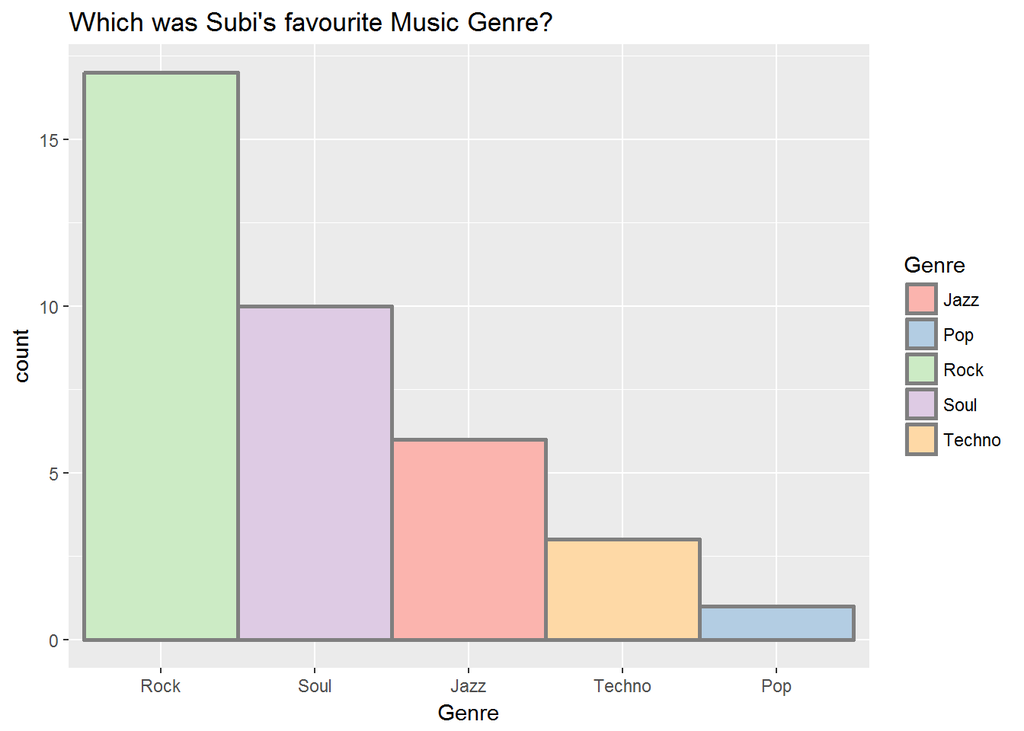

```r
genre_preference <- album_data %>%
  filter(personal_preferance == 1) %>%
  group_by(Genre) %>%
  summarise(count = n()) %>%
  arrange(desc(count))

genre_preference %>%
  ggplot(aes(x=reorder(Genre,-count), y=count, fill=Genre)) +
  geom_bar(width = 1, stat = "identity", color = "grey50", lwd = 1) +
  scale_fill_brewer(palette='Pastel1') +
  xlab("Genre") +
  ggtitle("Which was Subi's favourite Music Genre?")
```

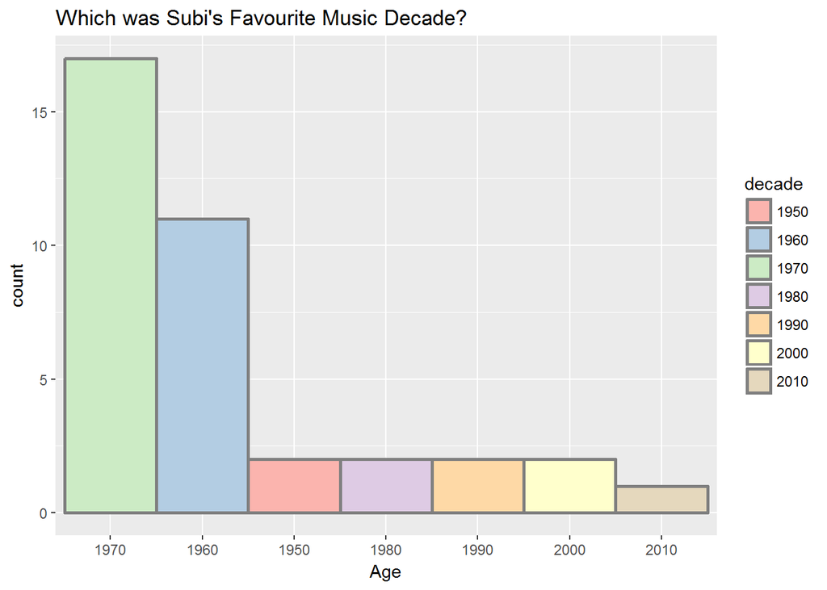

```r
decade_preference <- album_data %>%
  filter(personal_preferance == 1) %>%
  group_by(decade) %>%
  summarise(count = n()) %>%
  arrange(desc(count))

decade_preference %>%
  ggplot(aes(x=reorder(decade,-count), y=count, fill=decade)) +
  geom_bar(width = 1, stat = "identity", color = "grey50", lwd = 1) +
  scale_fill_brewer(palette='Pastel1') +
  xlab("Age") +
  ggtitle("Which was Subi's Favourite Music Decade?")
```

In terms of music taste, I am indeed a nostalgic person. Even now I still often enjoy listening to 60’s and 70’s albums. Most my favorite artists came from sixties and seventies, such as The kinks, Miles Davis, Carpenters, Billy Joel, The Beach Boys, Pink Floyd and Marvin Gaye. Sometimes I wish I could cross back to 50 years ago, and spend one night in a dark but wonderful underground livehouse, listening to my favourite idol’s songs.

```r
# list part of my favorite albums
album_data %>%
  filter(personal_preferance==1) %>%
  head(10)
```

```
## # A tibble: 10 × 8
##       X1  Year                                  Album          Artist
##    <chr> <int>                                  <chr>           <chr>
## 1      1  1966                             Pet Sounds  The Beach Boys
## 2     11  1959                           Kind of Blue     Miles Davis
## 3     23  1973                           Innervisions   Stevie Wonder
## 4     42  1973              The Dark Side of the Moon      Pink Floyd
## 5     46  1965                         A Love Supreme   John Coltrane
## 6     56  1976               Songs in the Key of Life   Stevie Wonder
## 7     69  1977                           The Stranger      Billy Joel
## 8     83  1967 I Never Loved a Man the Way I Love You Aretha Franklin
## 9     84  1968                              Lady Soul Aretha Franklin
## 10    86  1979                               The Wall      Pink Floyd
## # ... with 4 more variables: personal_preferance <int>, Genre <chr>,
## #   Subgenre <chr>, decade <fctr>
```

## Part 5: Limitation and Further Polishment Need to Be Done

#### Limitation

1. **Genre and subgenre classification might not be accurate.** Firstly, it’s very common that one album is a fusion mixed various genres. For instance, it’s hard to classify whether Acid Jazz belongs to Jazz or Techno. Secondly, the classification mechanics of Discog is unknown. Discog is a user-built database, so the genre labels are probably created by different users. The consistence of genre and subgenre naming could be an issue here.
2. Only little information about each albumn was collected.
3. The visulizations are mostly at general introductive level.

#### Further Polishment

1. Collect more dimensional data of each album to go deeper about music development trend, such as artist nationality, circulation volumes, award history, rating, republication times, music brand. It could be a tough work to collect these trivial snippets from different places, but it’s worthwhile to do that.
2. Introduce statistical regression analysis and hypothesis testing between variables to quantize this topic.
3. Introduce potential influence factors analysis of abrupt changes within specific music courses. Related contemporary music history materials should be included to enrich the report’s depth.
4. Add case study targeting one specific genre & subgenre, or decade. For instance, A Rock’n’roll big events time-line summarization would be nice to supplement much music industrial background.